# SE residual-coding expectation

## Question

with `a_i` and `b_i` fitted per Analysis. This document asks what that would buy on real `format_version` 2.0 Store Releases that already carry EAF:

- `finngen-r13` pilot-20, Dense;
- `ukb-b` Dense observed store;
- EBI GWAS Catalog EUR Hybrid case-control pilot.

The measurement is an estimate, not an implementation. `benchmarks/estimate_se_residual.py` samples real `se` and decoded `eaf`, fits the model, quantises the residual to `int8`, compresses sampled chunks with the current `se` compressor, and extrapolates to the full plane. Exception cells are charged conservatively at raw side-table cost (`int64` flat position + `float32` exact value).

## Headline

The storage upside is real, but the original all-or-none R² gate in #118 is probably the wrong decision rule. Low R² does not make the encoding inaccurate: the residual itself is what is quantised, and exceptions are exact. R² mostly predicts whether the residual plane is still small enough to be worth writing.

| store | current se GiB | current se B/cell | range 1.0 projected B/cell | range 1.0 saving | range 2.0 projected B/cell | range 2.0 saving | range 2.0 exception rate | min R² | analyses R²<0.99 |
| --- | --- | --- | --- | --- | --- | --- | --- | --- | --- |
| finngen-r13 pilot-20 | 0.54 | 1.366 | 0.509 | 62.7% | 0.332 | 75.7% | 0.10% | 0.980 | 20 |
| ukb-b dense observed | 19.73 | 0.857 | 0.114 | 86.7% | 0.069 | 92.0% | 0.00% | 0.330 | 1,165 |
| EBI GWAS Catalog hybrid | 0.18 | 1.656 | 1.052 | 36.4% | 0.893 | 46.1% | 0.41% | 0.590 | 8 |

At residual range ±2.0, all three stores stay below the 1% relative-error target for non-exception cells and below the 2% exception budget:

| component | sample cells | p99 relative error | max sampled relative error | exception rate |
| --- | --- | --- | --- | --- |
| finngen-r13 pilot-20 | 592,300 | 0.780% | 0.791% | 0.10% |
| ukb-b dense observed | 74,579,211 | 0.775% | 0.791% | 0.00% |
| EBI GWAS Catalog hybrid dense | 268,263 | 0.779% | 0.790% | 0.00% |
| EBI GWAS Catalog hybrid overflow | 5,969,974 | 0.779% | 0.791% | 0.42% |

## Actual sampled encode/decode round trip

This is the R² that matters for the representation: observed `log(SE)` versus `log(SE)` reconstructed from the MAF prediction plus the quantised residual. It is deliberately different from the lower MAF-only fit R² below. The side table restores every exception exactly.

| component | encoded cells compared | decoded-vs-true log(SE) R² |
| --- | --- | --- |
| finngen-r13 pilot-20 | 592,252 | 0.999989 |
| ukb-b dense observed | 41,532,140 | 0.999994 |
| EBI GWAS Catalog hybrid dense | 218,643 | 0.999979 |
| EBI GWAS Catalog hybrid overflow | 5,957,060 | 0.999991 |

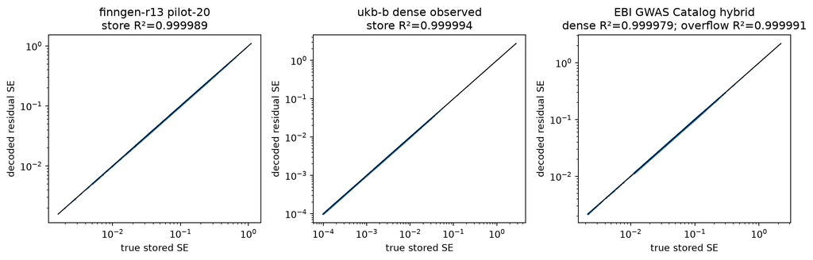

The near-one values are expected if the codec is correctly constructed: it stores the part the MAF-only model does not explain. They establish that a low MAF-only fit R² is not synonymous with inaccurate decoded SE. They do **not** by themselves prove the encoding is economically worthwhile; storage and query-coupling remain separate decisions.

## Storage footprint

| store | range | projected GiB | projected B/cell | saving GiB | saving | exception rate |
| --- | --- | --- | --- | --- | --- | --- |
| finngen-r13 pilot-20 | 0.25 | 0.55 | 1.396 | -0.01 | -2.2% | 6.36% |
| finngen-r13 pilot-20 | 0.5 | 0.32 | 0.818 | 0.22 | 40.1% | 2.34% |
| finngen-r13 pilot-20 | 1.0 | 0.20 | 0.509 | 0.34 | 62.7% | 0.67% |
| finngen-r13 pilot-20 | 2.0 | 0.13 | 0.332 | 0.41 | 75.7% | 0.10% |
| ukb-b dense observed | 0.25 | 6.20 | 0.269 | 13.52 | 68.6% | 0.13% |
| ukb-b dense observed | 0.5 | 4.05 | 0.176 | 15.68 | 79.5% | 0.04% |
| ukb-b dense observed | 1.0 | 2.62 | 0.114 | 17.11 | 86.7% | 0.00% |
| ukb-b dense observed | 2.0 | 1.58 | 0.069 | 18.15 | 92.0% | 0.00% |
| EBI GWAS Catalog hybrid | 0.25 | 0.49 | 4.500 | -0.31 | -171.8% | 49.10% |
| EBI GWAS Catalog hybrid | 0.5 | 0.28 | 2.574 | -0.10 | -55.4% | 20.37% |
| EBI GWAS Catalog hybrid | 1.0 | 0.11 | 1.052 | 0.07 | 36.4% | 3.34% |
| EBI GWAS Catalog hybrid | 2.0 | 0.10 | 0.893 | 0.08 | 46.1% | 0.41% |

Range ±2.0 is the storage-maximising choice in this sample because it nearly eliminates the side table. Its worst-case quantisation error is about `exp((2/127)/2)-1 = 0.79%`, still under #118’s 1% target. If the project wants stricter precision by default, ±1.0 is the relevant comparison: it still saves 63% on FinnGen and 87% on UKB, but misses the 2% exception budget on the EBI Hybrid pilot.

The realistic storage conclusion:

- **UKB is the strongest case**: same cohort across many Analyses, dense grid, EAF already amortised. The estimate is a 87–92% reduction in the SE plane.
- **FinnGen still saves materially** even though its R² is only ~0.98: 63–76% depending on whether ±1.0 or ±2.0 is accepted.
- **EBI Hybrid is not the original clean scenario**: heterogeneous studies and an Overflow Component widen residuals. It still saves about 46% at ±2.0, but only if the decision rule is byte/exception/precision-based rather than an R²≥0.99 all-or-none gate.

## Fit quality

| store | min R² | median R² | max R² | median slope | min EAF coverage | analyses R²<0.99 |
| --- | --- | --- | --- | --- | --- | --- |
| finngen-r13 pilot-20 | 0.980 | 0.982 | 0.982 | -0.530 | 100.00% | 20 |
| ukb-b dense observed | 0.330 | 0.992 | 0.999 | -0.502 | 100.00% | 1,165 |
| EBI GWAS Catalog hybrid | 0.590 | 0.804 | 0.995 | -0.608 | 98.43% | 8 |

The fitted slopes are close enough to the theoretical −0.5 for FinnGen and UKB to justify per-Analysis coefficients rather than one global constant. EBI Hybrid is wider and more heterogeneous, which is exactly where the format needs the byte comparison and exception accounting rather than a silent fallback.

## Query-speed expectation

Residual-coded SE changes the read path, but **does not add an EAF read to the current query facade**. Every standard `QueryFacade` method already decodes EAF and includes an `eaf` array in its raw result dictionary; the default human-readable TSV and the CLI JSON serializer merely suppress it from their output. With #118 the facade must order its reads so that its already-decoded EAF values are also passed to the SE decoder.

1. **Top-hit queries should be almost unchanged** if the top-hit index continues to carry decoded `float32 se`; the query never opens either the SE or EAF plane for indexed hits.
2. **PheWAS, range PheWAS, exact lookup and analysis extraction already read EAF.** Their incremental work is the small Analysis-coefficient gather, residual decode, and vectorised `exp(a + b x + residual)`. The smaller residual plane may compensate for that arithmetic; it must be benchmarked.
3. A future lean query API that truly avoids EAF output would still have to decode EAF internally when it requests residual-coded SE. That is a format coupling, not a current-query regression.

The sampled throughput below separates the current SE read, the EAF read that the facade already pays, and the residual-model arithmetic. It is not a full query benchmark.

| component | sample cells | current se read ns/cell | eaf read ns/cell | residual compute ns/cell |
| --- | --- | --- | --- | --- |
| finngen-r13 pilot-20 | 592,300 | 14.1 | 2076.8 | 39.3 |
| ukb-b dense observed | 74,579,211 | 2.7 | 33.2 | 29.9 |
| EBI GWAS Catalog hybrid dense | 268,263 | 26.0 | 1699.6 | 37.0 |
| EBI GWAS Catalog hybrid overflow | 5,969,974 | 2.8 | 340.9 | 28.4 |

The query-speed conclusion is therefore cautious: #118 is primarily a storage win. For the current facade, which already materialises EAF, the incremental cost is coefficients plus vectorised arithmetic rather than another EAF read; the smaller residual plane may offset it. The format still makes SE logically dependent on EAF, so dedicated benchmarks are required before landing.

## Recommendation

Implement #118 only behind a persisted plan with an explicit escape hatch back to `float16`. The decision should be based on measured bytes, exception fraction and the chosen precision bound, not R² alone.

A plausible acceptance rule from this evidence:

- fit per-Analysis `log(se) ~ a + b log(2f(1-f))`;
- test candidate residual ranges, probably including ±2.0;
- require finite EAF wherever finite SE is encoded this way, or record exact exceptions/fallback loudly;
- require projected compressed bytes plus side table to beat current `float16` by a meaningful margin;
- require the range’s half-step error bound to stay under the chosen relative-error contract;
- persist the coefficients, range, exception table and fallback decision in the Store Release plan.

Do not use an R²≥0.99 all-or-none rule as the only gate: it would reject every store measured here, including UKB, despite the largest estimated storage saving.